# R Seminar for Stem Week 2

Alin Morariu

06/11/2019

Recall from the first tutorial that for *every* new file we must load the packages we will be using for this tutorial. Accordingly, I recommend *always* including a “preamble” section where you load any and all packages you will need for your file. Put this section before your code (just under the title section which takes up the first few lines).

```r
library(tidyverse)
```

For the remainder of the tutorial, we will be working with the diamonds dataset. This dataset has just over 50,000 entries in it which gives us a large sample size and prevents us from examining every row of the data since that would be too time consuming. As such, we will be relying on summary statistics and plots to give us insight into the data.

Start by loading the data and previewing as we did last week.

```r
# load the data
data(diamonds)

# preview the data
glimpse(diamonds)
```

```
## Observations: 53,940
## Variables: 10
## $ carat   <dbl> 0.23, 0.21, 0.23, 0.29, 0.31, 0.24, 0.24, 0.26, 0.22, 0.…
## $ cut     <ord> Ideal, Premium, Good, Premium, Good, Very Good, Very Goo…
## $ color   <ord> E, E, E, I, J, J, I, H, E, H, J, J, F, J, E, E, I, J, J,…
## $ clarity <ord> SI2, SI1, VS1, VS2, SI2, VVS2, VVS1, SI1, VS2, VS1, SI1,…
## $ depth   <dbl> 61.5, 59.8, 56.9, 62.4, 63.3, 62.8, 62.3, 61.9, 65.1, 59…
## $ table   <dbl> 55, 61, 65, 58, 58, 57, 57, 55, 61, 61, 55, 56, 61, 54, …
## $ price   <int> 326, 326, 327, 334, 335, 336, 336, 337, 337, 338, 339, 3…
## $ x       <dbl> 3.95, 3.89, 4.05, 4.20, 4.34, 3.94, 3.95, 4.07, 3.87, 4.…
## $ y       <dbl> 3.98, 3.84, 4.07, 4.23, 4.35, 3.96, 3.98, 4.11, 3.78, 4.…
## $ z       <dbl> 2.43, 2.31, 2.31, 2.63, 2.75, 2.48, 2.47, 2.53, 2.49, 2.…
```

```r
# head(diamonds) is another option but glimpse works better here due to the number of columns
colnames(diamonds) # sometimes it's helpful to see just the column names (more)
```

```
##  [1] "carat"   "cut"     "color"   "clarity" "depth"   "table"   "price"
##  [8] "x"       "y"       "z"
```

```r
# Base R command to get column wise summary statistics of the data
summary(diamonds)
```

```
##      carat               cut        color        clarity
##  Min.   :0.2000   Fair     : 1610   D: 6775   SI1    :13065
##  1st Qu.:0.4000   Good     : 4906   E: 9797   VS2    :12258
##  Median :0.7000   Very Good:12082   F: 9542   SI2    : 9194
##  Mean   :0.7979   Premium  :13791   G:11292   VS1    : 8171
##  3rd Qu.:1.0400   Ideal    :21551   H: 8304   VVS2   : 5066
##  Max.   :5.0100                     I: 5422   VVS1   : 3655
##                                     J: 2808   (Other): 2531
##      depth           table           price             x
##  Min.   :43.00   Min.   :43.00   Min.   :  326   Min.   : 0.000
##  1st Qu.:61.00   1st Qu.:56.00   1st Qu.:  950   1st Qu.: 4.710
##  Median :61.80   Median :57.00   Median : 2401   Median : 5.700
##  Mean   :61.75   Mean   :57.46   Mean   : 3933   Mean   : 5.731
##  3rd Qu.:62.50   3rd Qu.:59.00   3rd Qu.: 5324   3rd Qu.: 6.540
##  Max.   :79.00   Max.   :95.00   Max.   :18823   Max.   :10.740
##
##        y                z
##  Min.   : 0.000   Min.   : 0.000
##  1st Qu.: 4.720   1st Qu.: 2.910
##  Median : 5.710   Median : 3.530
##  Mean   : 5.735   Mean   : 3.539
##  3rd Qu.: 6.540   3rd Qu.: 4.040
##  Max.   :58.900   Max.   :31.800
##
```

Now that we have an idea of the scale of our data we can start with some plots to gain some insight on their distribution. This is where our cheatsheets will come into play.

1. [dplyr](https://rstudio.com/wp-content/uploads/2015/02/data-wrangling-cheatsheet.pdf) for data wrangling
2. [ggplot2](https://rstudio.com/wp-content/uploads/2015/03/ggplot2-cheatsheet.pdf) for data visualization (plotting)

In order to see how individual variables behave we need to make one variable plots. Generally speaking, we make histograms for continuous variables, and bar graphs for categorical/factor variables. Below is an example of each.

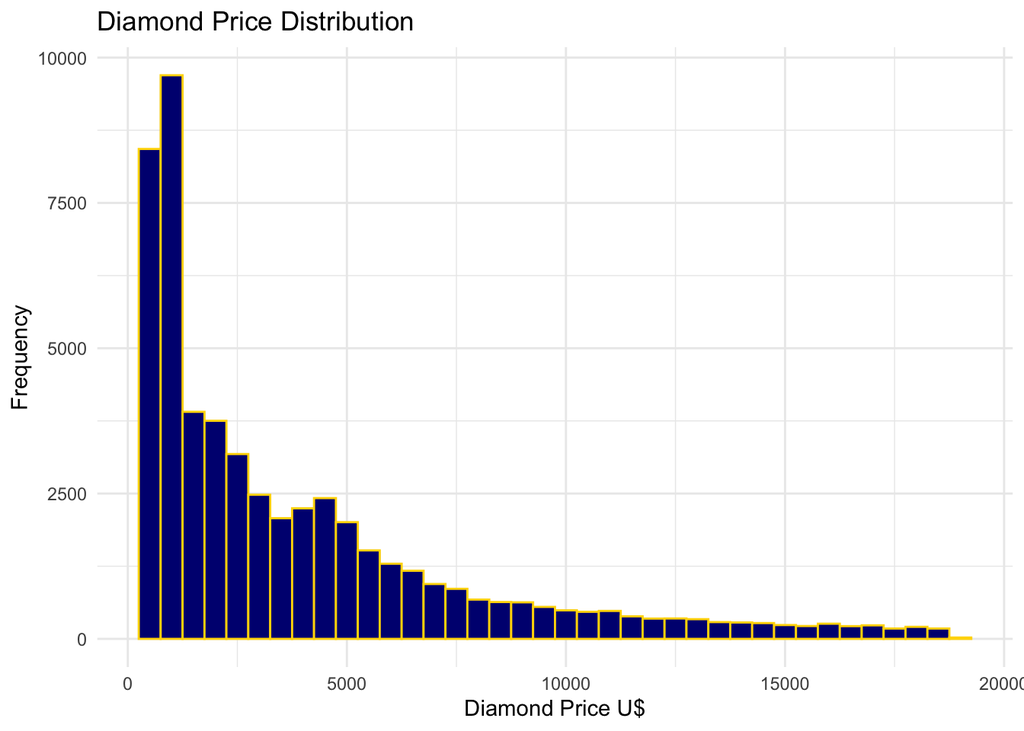

```r
# code is very similar to last week
# use the piping operator which passes the preceding argument as the first argument of the following function
plot1 <- diamonds %>% ggplot(aes(price)) +
  geom_histogram(binwidth=500, fill = "navy", color = "gold") +
  ggtitle("Diamond Price Distribution") + xlab("Diamond Price U$") + ylab("Frequency") +
  theme_minimal()

# have to call the object in order to see it
plot1
```

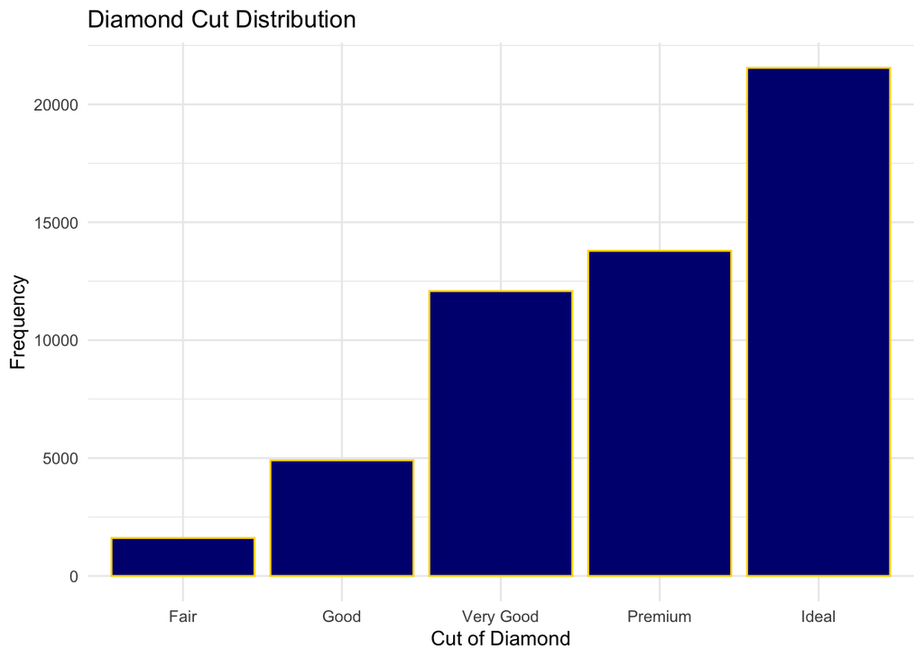

```r
plot2 <- diamonds %>% ggplot(aes(cut)) +
  geom_bar(fill = "navy", color = "gold") +
  ggtitle("Diamond Cut Distribution") + xlab("Cut of Diamond") + ylab("Frequency") +
  theme_minimal()

plot2
```

We can create 2-variable plots as well. The classic example is a dot plot.

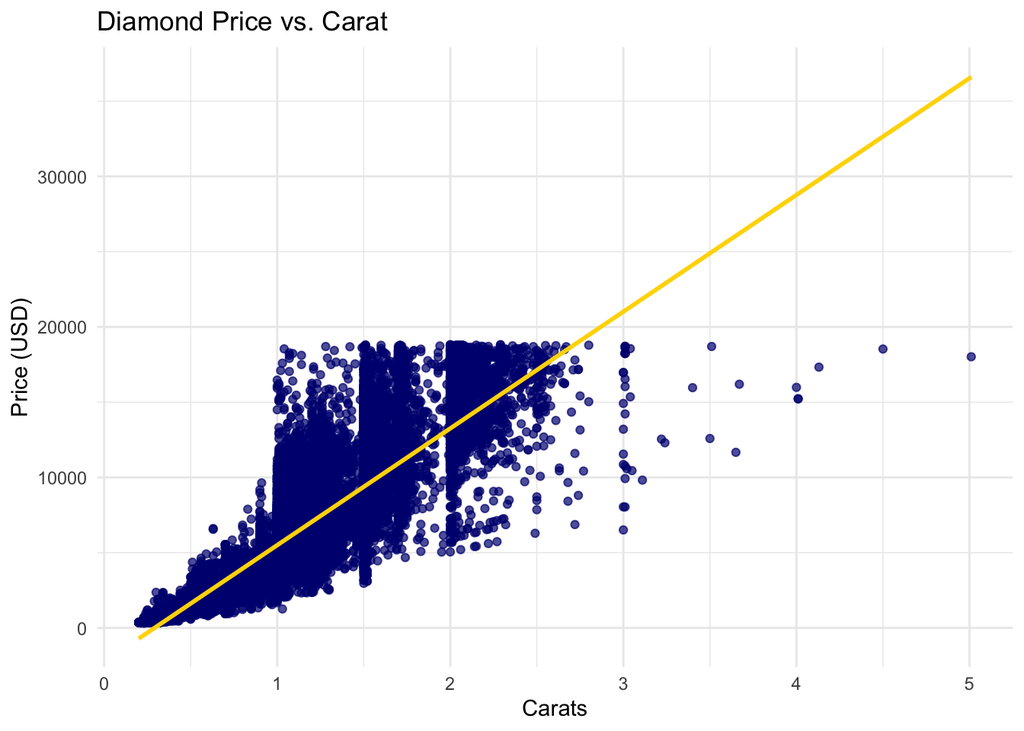

```r
plot3 <- diamonds %>% ggplot(aes(x = carat, y = price)) +
  geom_point(color = "navy", alpha = 0.7) +
  geom_smooth(method = "lm", color = "gold") +
  ggtitle("Diamond Price vs. Carat") + xlab("Carats") + ylab("Price (USD)") +
  theme_minimal()

plot3
```

#### Exercise

1. Create a bar graph for the color of the diamonds.
2. Create 2 more dot plots for any of the numerical variables. Do not include a line of best fit on one of them.

1. How many cost less than $500?

```r
diamonds %>%
  filter(price < 500)
```

```
## # A tibble: 1,729 x 10
##    carat cut       color clarity depth table price     x     y     z
##    <dbl> <ord>     <ord> <ord>   <dbl> <dbl> <int> <dbl> <dbl> <dbl>
##  1 0.23  Ideal     E     SI2      61.5    55   326  3.95  3.98  2.43
##  2 0.21  Premium   E     SI1      59.8    61   326  3.89  3.84  2.31
##  3 0.23  Good      E     VS1      56.9    65   327  4.05  4.07  2.31
##  4 0.290 Premium   I     VS2      62.4    58   334  4.2   4.23  2.63
##  5 0.31  Good      J     SI2      63.3    58   335  4.34  4.35  2.75
##  6 0.24  Very Good J     VVS2     62.8    57   336  3.94  3.96  2.48
##  7 0.24  Very Good I     VVS1     62.3    57   336  3.95  3.98  2.47
##  8 0.26  Very Good H     SI1      61.9    55   337  4.07  4.11  2.53
##  9 0.22  Fair      E     VS2      65.1    61   337  3.87  3.78  2.49
## 10 0.23  Very Good H     VS1      59.4    61   338  4     4.05  2.39
## # … with 1,719 more rows
```

2. How many cost less than $250?

```r
diamonds %>%
  filter(price < 250)
```

```
## # A tibble: 0 x 10
## # … with 10 variables: carat <dbl>, cut <ord>, color <ord>, clarity <ord>,
## #   depth <dbl>, table <dbl>, price <int>, x <dbl>, y <dbl>, z <dbl>
```

3. How many cost equal to $15,000 or more?

```r
diamonds %>%
  filter(price > 15000)
```

```
## # A tibble: 1,655 x 10
##    carat cut       color clarity depth table price     x     y     z
##    <dbl> <ord>     <ord> <ord>   <dbl> <dbl> <int> <dbl> <dbl> <dbl>
##  1  1.54 Premium   E     VS2      62.3    58 15002  7.31  7.39  4.58
##  2  1.19 Ideal     F     VVS1     61.5    55 15005  6.82  6.84  4.2
##  3  2.1  Premium   I     SI1      61.5    57 15007  8.25  8.21  5.06
##  4  1.69 Ideal     D     SI1      60.8    57 15011  7.69  7.71  4.68
##  5  1.5  Very Good G     VVS2     62.9    56 15013  7.22  7.32  4.57
##  6  1.73 Very Good G     VS1      62.8    57 15014  7.57  7.72  4.8
##  7  2.02 Premium   G     SI2      63      59 15014  8.05  7.95  5.03
##  8  2.05 Very Good F     SI2      61.9    56 15017  8.13  8.18  5.05
##  9  1.5  Very Good F     VS1      61.6    58 15022  7.35  7.43  4.55
## 10  1.82 Very Good G     SI1      62.7    58 15025  7.68  7.75  4.84
## # … with 1,645 more rows
```

4. How many diamonds cost between $2,00 and $7,500?

```r
diamonds %>%
  filter(price < 7500) %>%
  filter(price > 2500)
```

```
## # A tibble: 18,012 x 10
##    carat cut       color clarity depth table price     x     y     z
##    <dbl> <ord>     <ord> <ord>   <dbl> <dbl> <int> <dbl> <dbl> <dbl>
##  1  0.7  Ideal     E     SI1      62.5    57  2757  5.7   5.72  3.57
##  2  0.86 Fair      E     SI2      55.1    69  2757  6.45  6.33  3.52
##  3  0.7  Ideal     G     VS2      61.6    56  2757  5.7   5.67  3.5
##  4  0.71 Very Good E     VS2      62.4    57  2759  5.68  5.73  3.56
##  5  0.78 Very Good G     SI2      63.8    56  2759  5.81  5.85  3.72
##  6  0.7  Good      E     VS2      57.5    58  2759  5.85  5.9   3.38
##  7  0.7  Good      F     VS1      59.4    62  2759  5.71  5.76  3.4
##  8  0.96 Fair      F     SI2      66.3    62  2759  6.27  5.95  4.07
##  9  0.73 Very Good E     SI1      61.6    59  2760  5.77  5.78  3.56
## 10  0.8  Premium   H     SI1      61.5    58  2760  5.97  5.93  3.66
## # … with 18,002 more rows
```

5. Create a histogram of the diamond prices for only the diamonds selected in Q4.

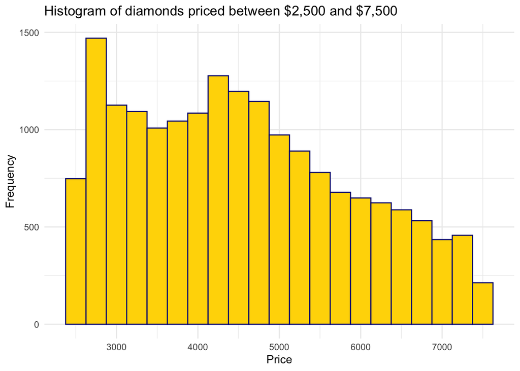

```r
diamonds %>%
  filter(price < 7500) %>%
  filter(price > 2500) %>%
  ggplot(aes(price)) +
  geom_histogram(binwidth = 250, color = "navy", fill = "gold") +
  ggtitle("Histogram of diamonds priced between $2,500 and $7,500") + xlab("Price") + ylab("Frequency") +
  theme_minimal()
```

You are encouraged to tsary out more of these subsetting problems on your own.

# Linear Models

For the remainder of this document we will go over linear regression (i.e. putting a straight line through things). The goal here is to avoid all of the gory details of the math behind linear regression and provide you a practical set of tools for fitting the model in R and assessing the quality of the fit.

Data comes pairwise. For every x value we have a corresponding y value. Our model will put a straight line through all of our pairings such that the line is as close as possible to all the points simultaneously. The difference between what our y value and the predicted y value (comes from the y=mx+b equation we are overlaying over the data) is called the error.

1. Errors are independent (randomness)
2. Errors are normally distributed

### Fitting the model

We will fit the model using the base R lm function.

```r
?lm # see documentation of the function

# pick your covariates - the variables that go into the regression
colnames(diamonds)
```

```
##  [1] "carat"   "cut"     "color"   "clarity" "depth"   "table"   "price"
##  [8] "x"       "y"       "z"
```

```r
# start with a simple 2 variable model
lm1 <- lm(price ~ carat, data = diamonds)
lm1
```

```
##
## Call:
## lm(formula = price ~ carat, data = diamonds)
##
## Coefficients:
## (Intercept)        carat
##       -2256         7756
```

The above code outputs the respective paramteres of a line, namely the slope and intercept. Here is the code for what this regression looks like.

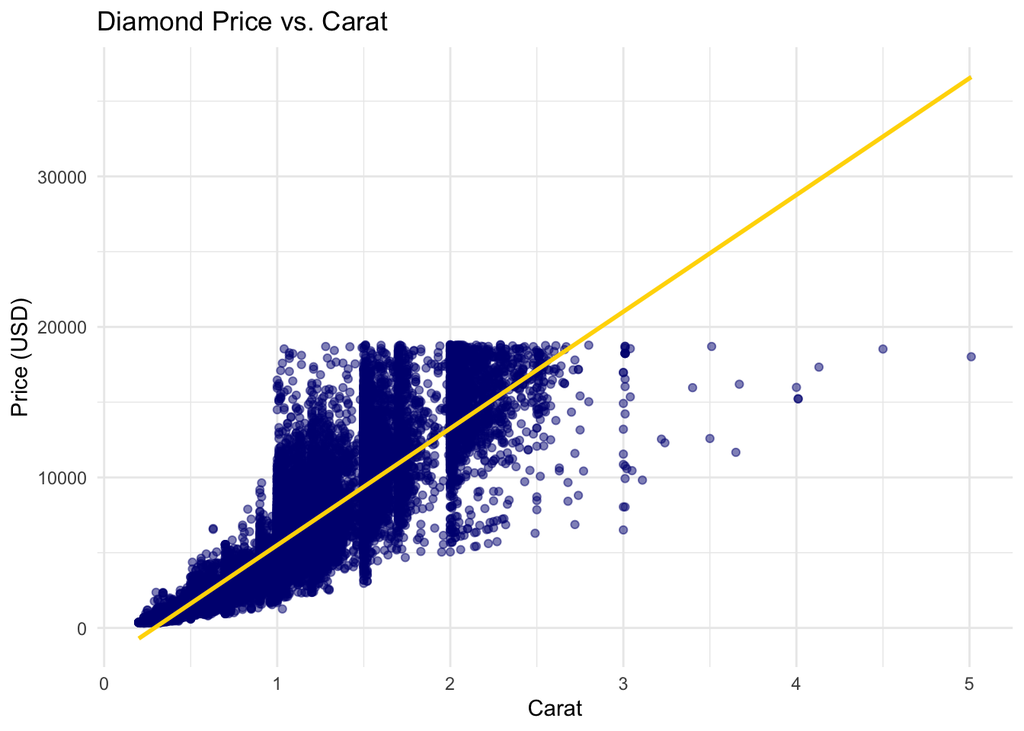

```r
plot1_lm <- diamonds %>% ggplot(aes(x = carat, y = price)) +
  geom_point(colour = "navy", alpha = 0.5) +
  geom_smooth( method = "lm", colour = "gold")+
  ggtitle("Diamond Price vs. Carat") + xlab("Carat") + ylab("Price (USD)") +
  theme_minimal()
plot1_lm
```

Now to get some details about the fit. There are 2 main analyses that we perform: a significance analysis and a visual diagnostic.

Let’s start with the visual diagnostics.

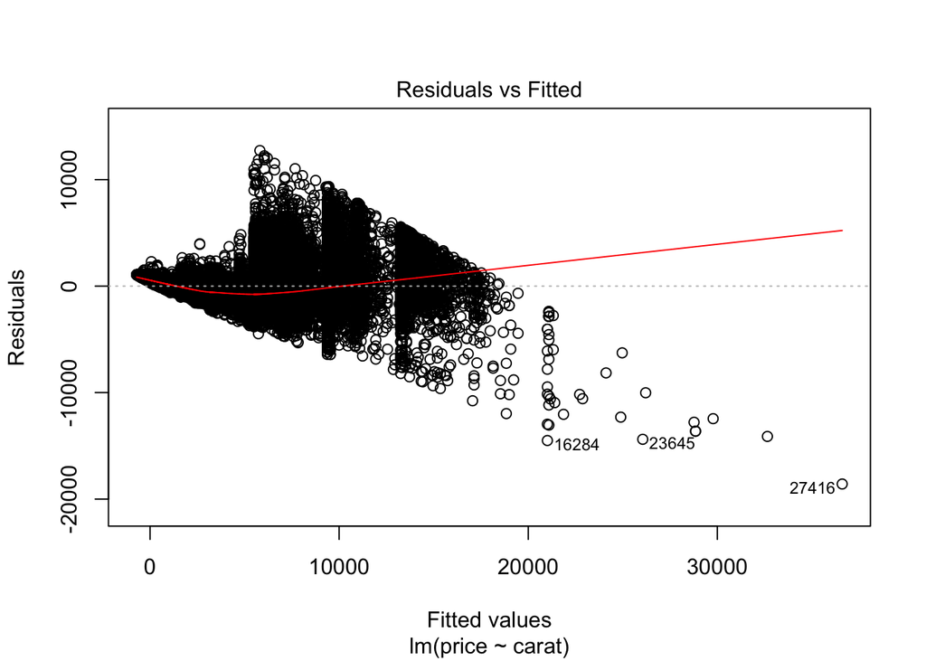

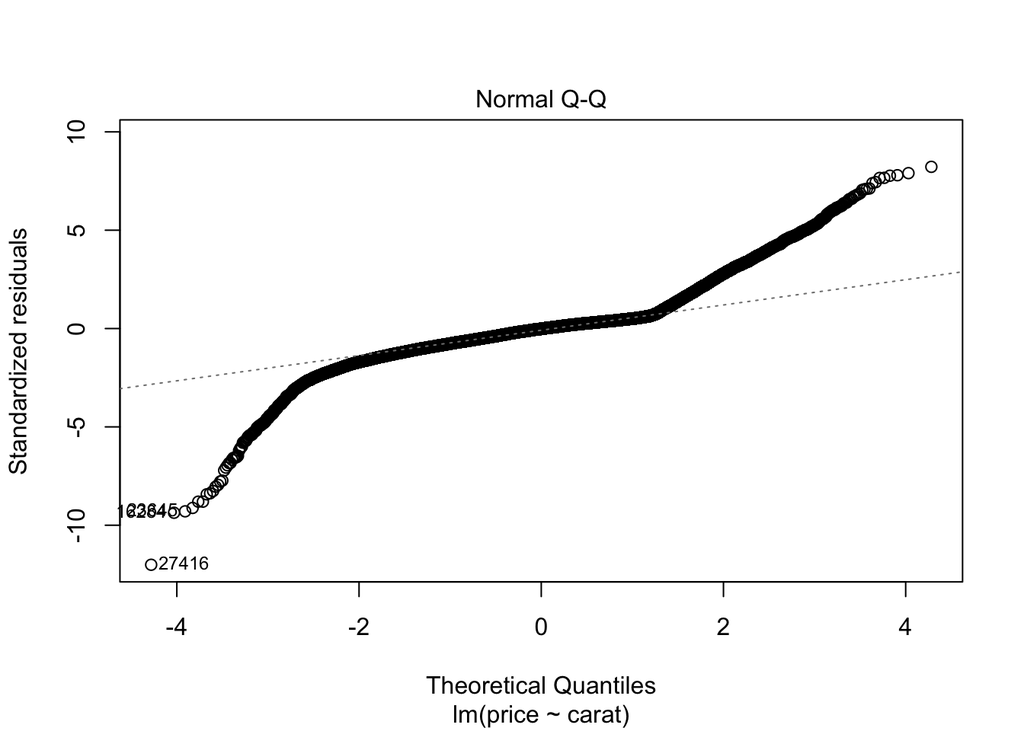

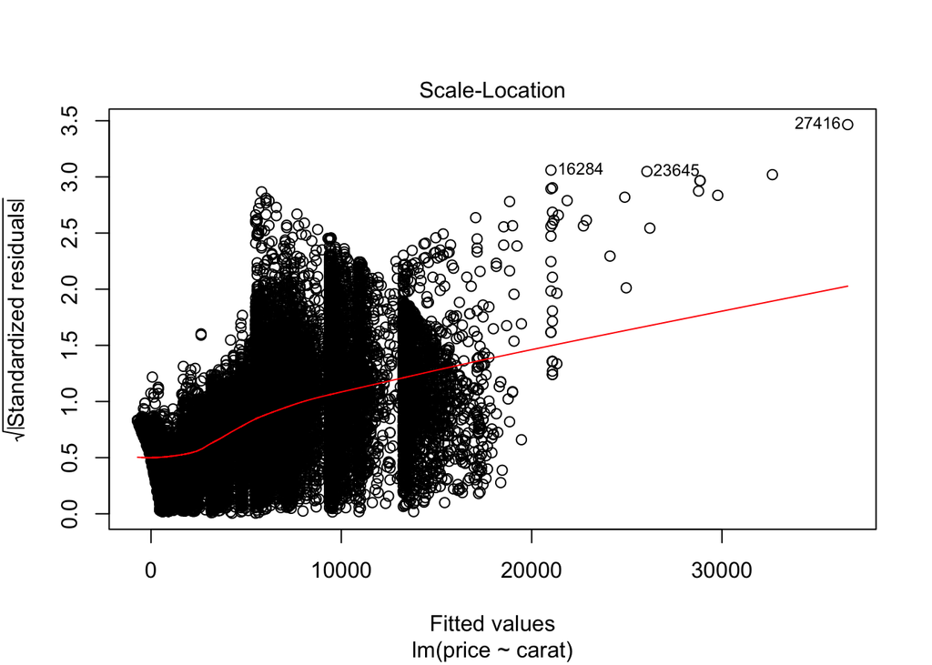

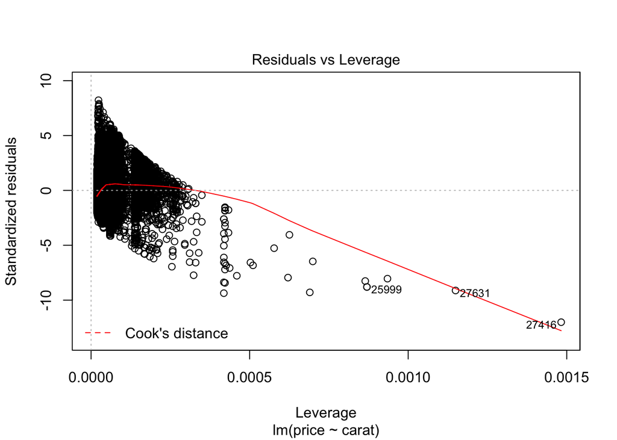

```r
plot(lm1)
```

Out of these 4 graphs, the three most important ones are the “Residuals vs. Fitted” plot, the “Normal-QQ” plot, and the “Residual vs. Leverage” plot.

#### “Residuals vs. Fitted” plot

Look for any patterns or clustering. You essentially want to see “randomness” or no patterns. If no patterns are visible, then assumption 1 from earlier is not violated.

#### “Normal-QQ” plot

This plot checks the second assumption. You want the points to lie on the dotted lined. If the points are *mostly* on the dotted line, assumption 2 is not violated.

#### “Residual vs. Leverage” plot

This plot is useful for checking for outliers. If you have any points outside of the dotted lines (labelled Cook’s distance) you can remove those points and refit the regression.

Now for the significance analysis. We will use the summamry function on our linear model.

```r
summary(lm1)
```

```
##
## Call:
## lm(formula = price ~ carat, data = diamonds)
##
## Residuals:
##      Min       1Q   Median       3Q      Max
## -18585.3   -804.8    -18.9    537.4  12731.7
##
## Coefficients:
##             Estimate Std. Error t value Pr(>|t|)
## (Intercept) -2256.36      13.06  -172.8   <2e-16 ***
## carat        7756.43      14.07   551.4   <2e-16 ***
## ---
## Signif. codes:  0 '***' 0.001 '**' 0.01 '*' 0.05 '.' 0.1 ' ' 1
##
## Residual standard error: 1549 on 53938 degrees of freedom
## Multiple R-squared:  0.8493, Adjusted R-squared:  0.8493
## F-statistic: 3.041e+05 on 1 and 53938 DF,  p-value: < 2.2e-16
```

The table provides us with estimates of the parameters along with their respective standard deviations. Our major concern is the last column which tells us the p-value of the respective parameter. We always set a significance level (typically it is 0.05). If the p-value is smaller than 0.05 then we can say that parameter (and the corresponding covariate, in this case the carat) is an important predictor of the diamond price. Note that regressions can have more than one parameter.

#### Exercise

1. Add 3 additional parameters to your linear model by using the + operator in the formula section of the lm function.